# LB-SPR

Yolanda Vila Gordillo

26/08/2020

## LB-SPR Análisis de Sensibilidad

Empezamos cargando la librería.

```r
library(LBSPR)
```

###Usamos los datos para Nephrops FU2627 de los machos

Los datos del ciclo vital recogidos de la literatura son (en base a LH Invariants analysis):

${M/k}^{LIT}$=2

$L_{inf}^{LIT}$=80

M = 0.3

L50=28

L95=32.2

Con la información anterior creamos un objecto “LB_pars”.

```r
Nepmales1Pars <- new("LB_pars")
```

```
## A blank LB_pars object created
```

```
## Default values have been set for some parameters
```

```r
Nepmales1Pars@Linf <- 80
Nepmales1Pars@L50 <- 28
Nepmales1Pars@L95 <- 32.2
Nepmales1Pars@MK <- 2
Nepmales1Pars@M <- 0.3
Nepmales1Pars@L_units <- "mm"
```

Para poder aplicar el método necesitamos leer el archivo csv con las frecuencias de tallas y crear con dicha información un objecto “LB_lengths”.

```r
NepmalesLenFreq1 <- new("LB_lengths", LB_pars=Nepmales1Pars, file="FU2627_tallasMales_1988_2019_2.csv", dataType="freq", header=TRUE)
NepmalesLenFreq1@L_units <- Nepmales1Pars@L_units
```

A partir de la informacón creada ya podemos aplicar nuestro modelo.

El *ESCENARIO DE REFERENCIA* es el que utiliza los parámetros descritos con anterioridad es decir el que usa ${M/k}^{LIT}$ y $L_{inf}^{LIT}$. Los resultados derivados de modificaciones en los valores de $L_{inf}$ y ${M/k}$ se compararan siempre con este escenario que es el que usaríamos en caso de no estar interesados en ver la sensibilidad del método a la correcta especificación de los mismos.

```r
Fit1 <- LBSPRfit(Nepmales1Pars, NepmalesLenFreq1)
```

```
## Fitting model
```

```
## Year:
```

```
## 1
```

```
## 2
```

```
## 3
```

```
## 4
```

```
## 5
```

```
## 6
```

```
## 7
```

```
## 8
```

```
## 9
```

```
## 10
```

```
## 11
```

```
## 12
```

```
## 13
```

```
## 14
```

```
## 15
```

```
## 16
```

```
## 17
```

```
## 18
```

```
## 19
```

```
## 20
```

```
## 21
```

```
## 22
```

```
## 23
```

```
## 24
```

```
## 25
```

```
## 26
```

```
## 27
```

```
## 28
```

```
## 29
```

```
## 30
```

```
## 31
```

```
## 32
```

En las siguientes secciones vemos los resultamos considerando modificaciones de dichos parámetros.

## ESCENARIOS MODIFICADOS USANDO LOS DIFERENTES VALORES PARA EL PARÁMETRO @MK

1. Primero infraestimando (${M/k}^{LIT}$ multiplicado por 0.75):

```r
Nepmales1ParsMK <-Nepmales1Pars
Nepmales1ParsMK@MK <- 0.75*2


NepmalesLenFreq1MK <- new("LB_lengths", LB_pars=Nepmales1ParsMK, file="FU2627_tallasMales_1988_2019_2.csv", dataType="freq", header=TRUE)
NepmalesLenFreq1MK@L_units <- Nepmales1ParsMK@L_units


Fit1MK <- LBSPRfit(Nepmales1ParsMK, NepmalesLenFreq1MK)
```

```
## Fitting model
```

```
## Year:
```

```
## 1
```

```
## 2
```

```
## 3
```

```
## 4
```

```
## 5
```

```
## 6
```

```
## 7
```

```
## 8
```

```
## 9
```

```
## 10
```

```
## 11
```

```
## 12
```

```
## 13
```

```
## 14
```

```
## 15
```

```
## 16
```

```
## 17
```

```
## 18
```

```
## 19
```

```
## 20
```

```
## 21
```

```
## 22
```

```
## 23
```

```
## 24
```

```
## 25
```

```
## 26
```

```
## 27
```

```
## 28
```

```
## 29
```

```
## 30
```

```
## 31
```

```
## 32
```

2. Segundo sobrestimando (${M/k}^{LIT}$ multiplicado por 1.25):

```r
Nepmales2ParsMK <-Nepmales1Pars
Nepmales2ParsMK@MK <- 1.25*2


NepmalesLenFreq2MK <- new("LB_lengths", LB_pars=Nepmales2ParsMK, file="FU2627_tallasMales_1988_2019_2.csv", dataType="freq", header=TRUE)
NepmalesLenFreq2MK@L_units <- Nepmales2ParsMK@L_units


Fit2MK <- LBSPRfit(Nepmales2ParsMK, NepmalesLenFreq2MK)
```

```
## Fitting model
```

```
## Year:
```

```
## 1
```

```
## 2
```

```
## 3
```

```
## 4
```

```
## 5
```

```
## 6
```

```
## 7
```

```
## 8
```

```
## 9
```

```
## 10
```

```
## 11
```

```
## 12
```

```
## 13
```

```
## 14
```

```
## 15
```

```
## 16
```

```
## 17
```

```
## 18
```

```
## 19
```

```
## 20
```

```
## 21
```

```
## 22
```

```
## 23
```

```
## 24
```

```
## 25
```

```
## 26
```

```
## 27
```

```
## 28
```

```
## 29
```

```
## 30
```

```
## 31
```

```
## 32
```

3. Tercero usando el valor por defecto de 1.5.

```r
Nepmales3ParsMK <-Nepmales1Pars
Nepmales3ParsMK@MK <- 1.5

NepmalesLenFreq3MK <- new("LB_lengths", LB_pars=Nepmales3ParsMK, file="FU2627_tallasMales_1988_2019_2.csv", dataType="freq", header=TRUE)
NepmalesLenFreq3MK@L_units <- Nepmales3ParsMK@L_units


Fit3MK <- LBSPRfit(Nepmales3ParsMK, NepmalesLenFreq3MK)
```

```
## Fitting model
```

```
## Year:
```

```
## 1
```

```
## 2
```

```
## 3
```

```
## 4
```

```
## 5
```

```
## 6
```

```
## 7
```

```
## 8
```

```
## 9
```

```
## 10
```

```
## 11
```

```
## 12
```

```
## 13
```

```
## 14
```

```
## 15
```

```
## 16
```

```
## 17
```

```
## 18
```

```
## 19
```

```
## 20
```

```
## 21
```

```
## 22
```

```
## 23
```

```
## 24
```

```
## 25
```

```
## 26
```

```
## 27
```

```
## 28
```

```
## 29
```

```
## 30
```

```
## 31
```

```
## 32
```

## ESCENARIOS MODIFICADOS USANDO LOS DIFERENTES VALORES PARA EL PARÁMETRO @Linf

1. Primero infraestimando ($L_{inf}^{LIT}$ multiplicado por 0.75):

```r
Nepmales1ParsLinf <-Nepmales1Pars
Nepmales1ParsLinf@Linf <- 0.75*80

NepmalesLenFreq1Linf <- new("LB_lengths", LB_pars=Nepmales1ParsLinf, file="FU2627_tallasMales_1988_2019_2.csv", dataType="freq", header=TRUE)
NepmalesLenFreq1Linf@L_units <- Nepmales1ParsLinf@L_units


Fit1Linf <- LBSPRfit(Nepmales1ParsLinf, NepmalesLenFreq1Linf)
```

```
## Fitting model
```

```
## Year:
```

```
## 1
```

```
## 2
```

```
## 3
```

```
## 4
```

```
## 5
```

```
## 6
```

```
## 7
```

```
## 8
```

```
## 9
```

```
## 10
```

```
## 11
```

```
## 12
```

```
## 13
```

```
## 14
```

```
## 15
```

```
## 16
```

```
## 17
```

```
## 18
```

```
## 19
```

```
## 20
```

```
## 21
```

```
## 22
```

```
## 23
```

```
## 24
```

```
## 25
```

```
## 26
```

```
## 27
```

```
## 28
```

```
## 29
```

```
## 30
```

```
## 31
```

```
## 32
```

2. Segundo sobrestimando ($L_{inf}^{LIT}$ multiplicado por 1.25):

```r
Nepmales2ParsLinf <-Nepmales1Pars
Nepmales2ParsLinf@Linf <- 1.25*80

NepmalesLenFreq2Linf <- new("LB_lengths", LB_pars=Nepmales2ParsLinf, file="FU2627_tallasMales_1988_2019_2.csv", dataType="freq", header=TRUE)
NepmalesLenFreq2Linf@L_units <- Nepmales2ParsLinf@L_units


Fit2Linf <- LBSPRfit(Nepmales2ParsLinf, NepmalesLenFreq2Linf)
```

```
## Fitting model
```

```
## Year:
```

```
## 1
```

```
## 2
```

```
## 3
```

```
## 4
```

```
## 5
```

```
## 6
```

```
## 7
```

```
## 8
```

```
## 9
```

```
## 10
```

```
## 11
```

```
## 12
```

```
## 13
```

```
## 14
```

```
## 15
```

```
## 16
```

```
## 17
```

```
## 18
```

```
## 19
```

```
## 20
```

```
## 21
```

```
## 22
```

```
## 23
```

```
## 24
```

```
## 25
```

```
## 26
```

```
## 27
```

```
## 28
```

```
## 29
```

```
## 30
```

```
## 31
```

```
## 32
```

## RESUMEN DE LA INFORMACIÓN

Crearemos dos gráficos en los cuales veremos las estimaciones de F/M y de SPR para los diferentes escenarios.

Gráfico SPR:

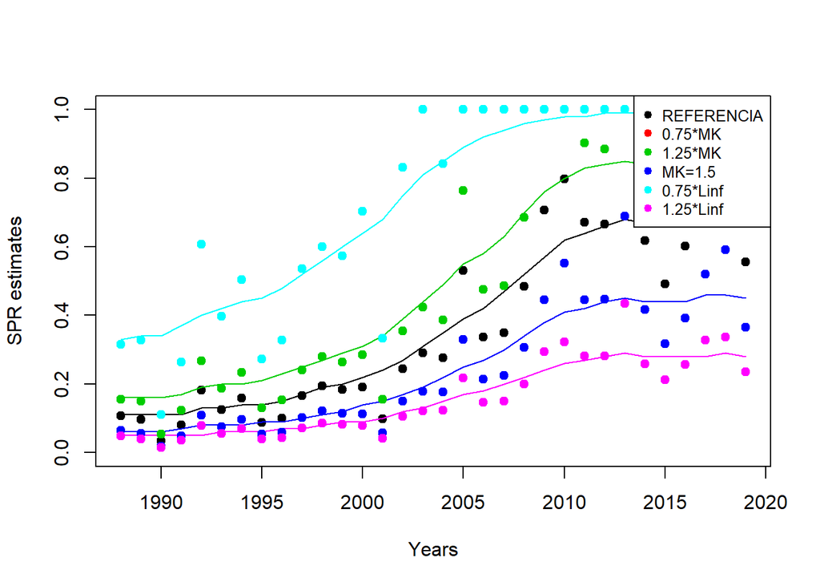

```r
smoothEsts1 <- data.frame(Fit1@Ests)
smoothEsts1MK <- data.frame(Fit1MK@Ests)
smoothEsts2MK <- data.frame(Fit2MK@Ests)
smoothEsts3MK <- data.frame(Fit3MK@Ests)
smoothEsts1Linf <- data.frame(Fit1Linf@Ests)
smoothEsts2Linf <- data.frame(Fit2Linf@Ests)


spr1=Fit1@SPR
sprmk1=Fit1MK@SPR
sprmk2=Fit2MK@SPR
sprmk3=Fit3MK@SPR
sprL1=Fit1Linf@SPR
sprL2=Fit2Linf@SPR



plot(1988:2019,spr1,ylim=c(0,1),xlab="Years",ylab="SPR estimates",pch=19)

lines(1988:2019, smoothEsts1$SPR, lwd = 1,col="black")
lines(1988:2019, smoothEsts1MK$SPR, lwd = 1,col=2)
lines(1988:2019, smoothEsts2MK$SPR, lwd = 1,col=3)
lines(1988:2019, smoothEsts3MK$SPR, lwd = 1,col=4)
lines(1988:2019, smoothEsts1Linf$SPR, lwd = 1,col=5)
lines(1988:2019, smoothEsts2Linf$SPR, lwd = 1,col=6)


points(1988:2019, sprmk1,col=2,pch=19)
points(1988:2019, sprmk2,col=3,pch=19)
points(1988:2019, sprmk3,col=4,pch=19)
points(1988:2019, sprL1,col=5,pch=19)
points(1988:2019, sprL2,col=6,pch=19)

legend("topright", legend=c("REFERENCIA", "0.75*MK","1.25*MK","MK=1.5","0.75*Linf","1.25*Linf"),
       col=c("black", 2:6), pch=19, cex=0.8)
```

Gráfico F/M:

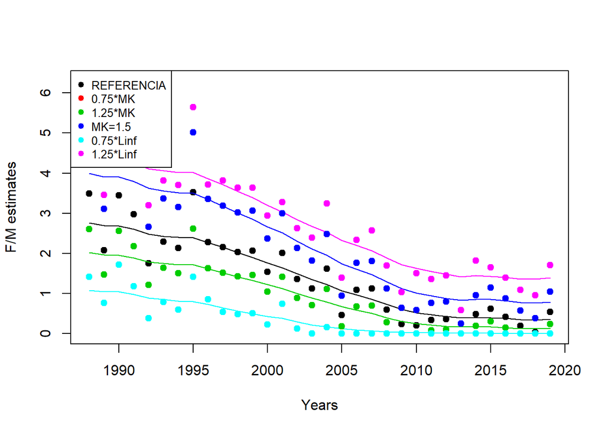

```r
fm1=Fit1@FM
fmmk1=Fit1MK@FM
fmmk2=Fit2MK@FM
fmmk3=Fit3MK@FM
fmL1=Fit1Linf@FM
fmL2=Fit2Linf@FM

plot(1988:2019,fm1,ylim=c(0,6.3),xlab="Years",ylab="F/M estimates",pch=19)

lines(1988:2019, smoothEsts1$FM, lwd = 1,col="black")
lines(1988:2019, smoothEsts1MK$FM, lwd = 1,col=2)
lines(1988:2019, smoothEsts2MK$FM, lwd = 1,col=3)
lines(1988:2019, smoothEsts3MK$FM, lwd = 1,col=4)
lines(1988:2019, smoothEsts1Linf$FM, lwd = 1,col=5)
lines(1988:2019, smoothEsts2Linf$FM, lwd = 1,col=6)


points(1988:2019, fmmk1,col=2,pch=19)
points(1988:2019, fmmk2,col=3,pch=19)
points(1988:2019, fmmk3,col=4,pch=19)
points(1988:2019, fmL1,col=5,pch=19)
points(1988:2019, fmL2,col=6,pch=19)

legend("topleft", legend=c("REFERENCIA", "0.75*MK","1.25*MK","MK=1.5","0.75*Linf","1.25*Linf"),
       col=c("black", 2:6), pch=19, cex=0.8)
```

#para plotear selectivity, F/M, SP

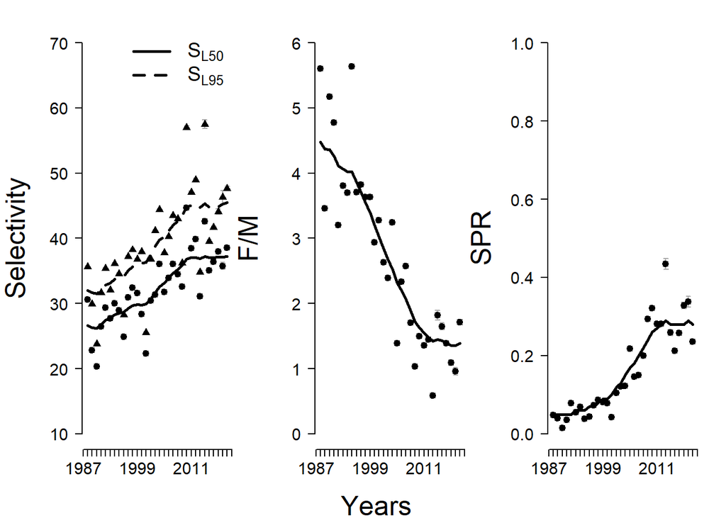

```r
plotEsts(Fit2Linf)
```